# Lecture 27a: regression walkthrough with lion data

brouwern@gmail.com

November 30, 2016

NOTE: Any changes to this document will be announced via the class Facebook page ([CalU EcoStats](https://www.facebook.com/groups/930301587096169/)) and via email.

# Lion data Table 17.1-1, pg 542

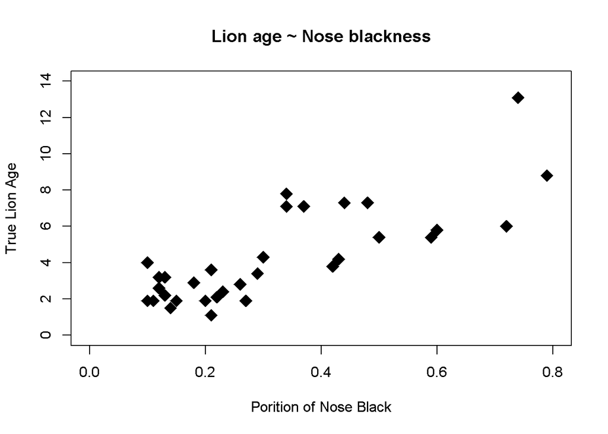

## Regression of Lion Data

Fit Regression models

```r
## Null model: no relationship between how black nose is and true age
lion.null <- lm(age.years ~ 1,   # What does "~ 1 " tell R?
               data = lions)


## ALt model: Age can be predicted by portion of nose that is black
lion.alt <- lm(age.years ~ portion.black,
               data = lions)
```

## Visualize the hypotheses posed by the models

Can you draw the hypotheses?

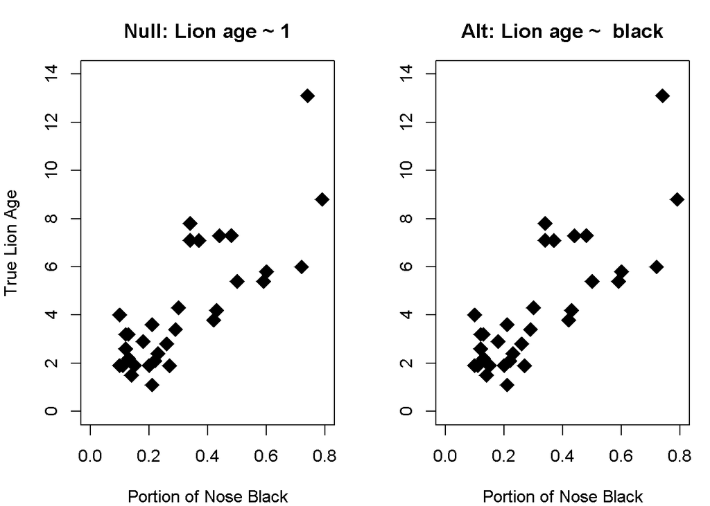

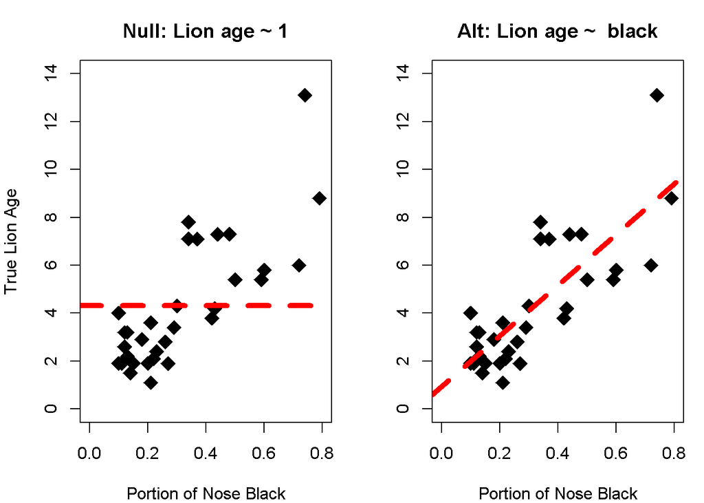

## Regression Model Output

### Standard way of getting output with summary() command

```
##
## Call:
## lm(formula = age.years ~ portion.black, data = lions)
##
## Residuals:
##     Min      1Q  Median      3Q     Max
## -2.5457 -1.1457 -0.3384  0.9245  4.3426
##
## Coefficients:
##               Estimate Std. Error t value Pr(>|t|)
## (Intercept)     0.9262     0.5591   1.657    0.108
## portion.black  10.5827     1.4884   7.110 6.59e-08 ***
## ---
## Signif. codes:  0 '***' 0.001 '**' 0.01 '*' 0.05 '.' 0.1 ' ' 1
##
## Residual standard error: 1.66 on 30 degrees of freedom
## Multiple R-squared:  0.6276, Adjusted R-squared:  0.6152
## F-statistic: 50.55 on 1 and 30 DF,  p-value: 6.59e-08
```

This gives a lot of somewhat cluttered output

### Just look at regression coefficients

```
##               Estimate Std. Error t value Pr(>|t|)
## (Intercept)      0.926      0.559   1.657    0.108
## portion.black   10.583      1.488   7.110    0.000
```

### Questions you should be able to answer:

- Why is one of the p-values equal to zero?
- Which one is the slope of the line?
- What is the biological meaning of a non-significant intercept?

## The regression model tells us the equation of the line

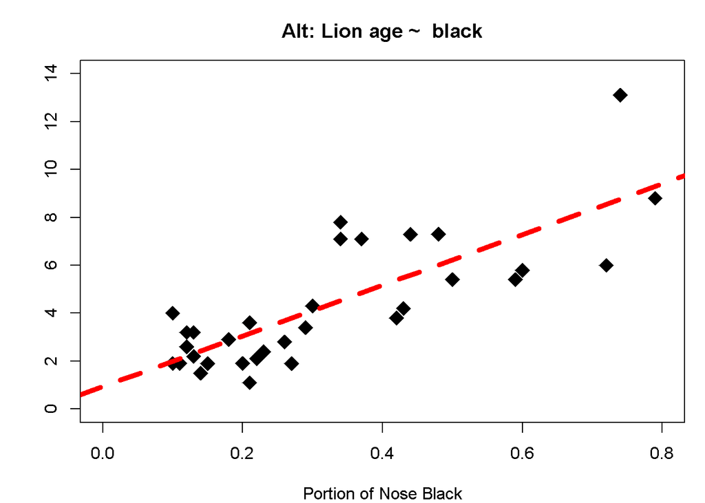

```
##   (Intercept) portion.black
##     0.9262292    10.5826652
```

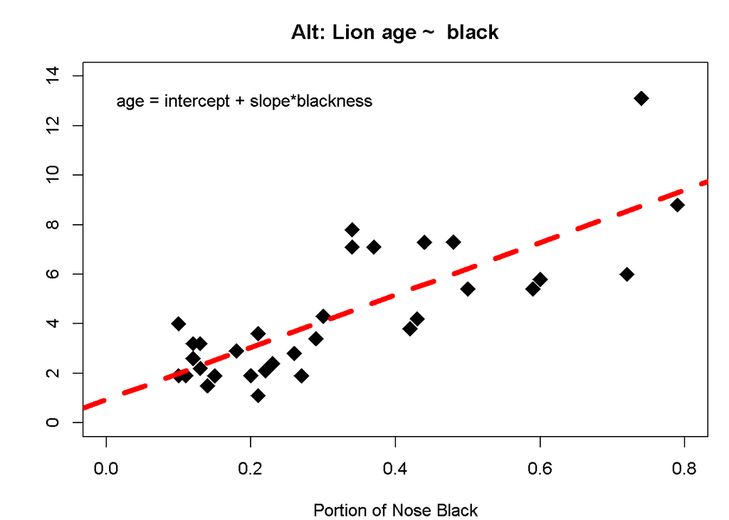

```
##   (Intercept) portion.black
##     0.9262292    10.5826652
```

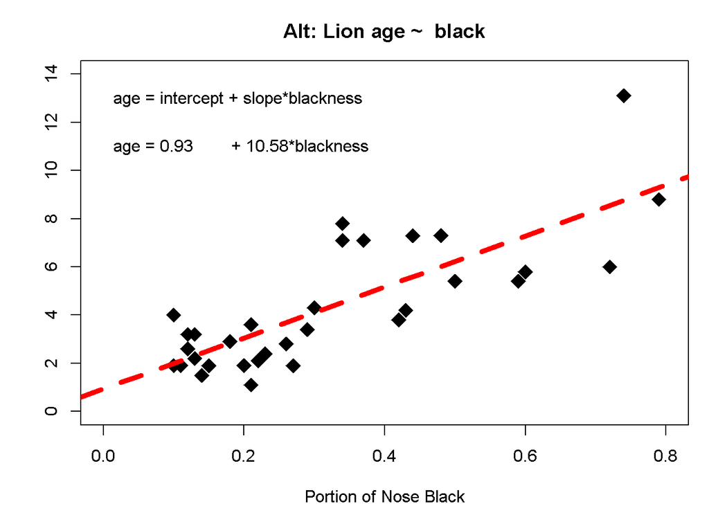

## Predictions from a model

- Say we take a picture of a lion and determine that the portion of its nose that is black is 0.65 (65%)
- What is the *predicted* age of the lion

```
##   (Intercept) portion.black
##     0.9262292    10.5826652
```

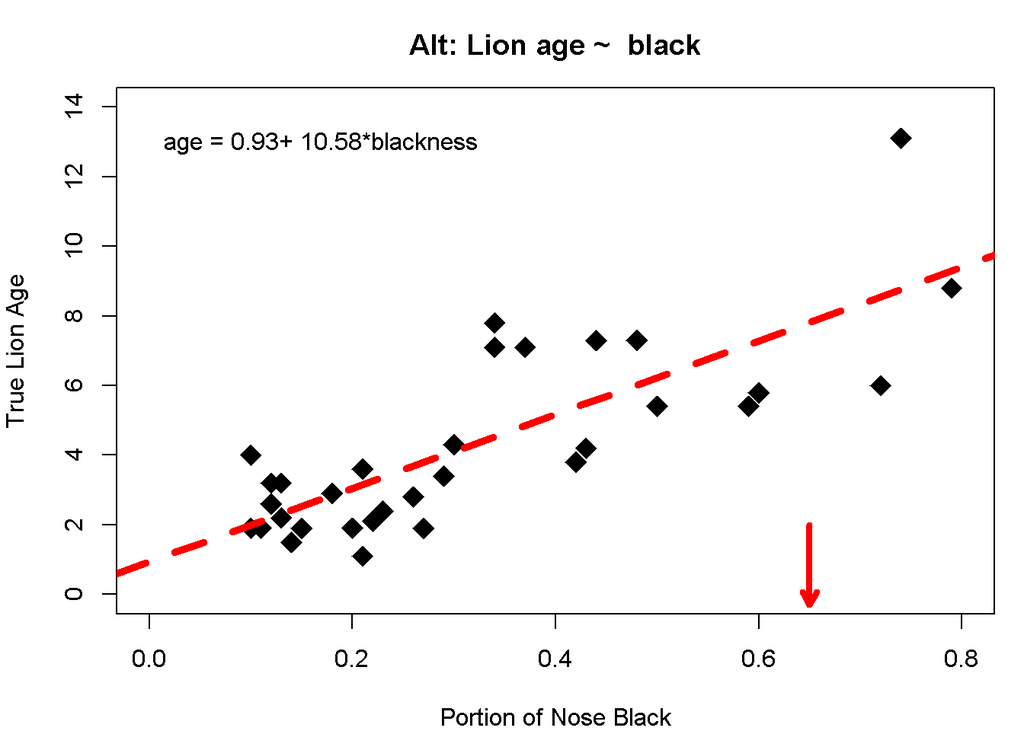

Points along the regression lines can be thought of as predictions for each value of x if we found a new lion with the value of x.

```
##   (Intercept) portion.black
##     0.9262292    10.5826652
```

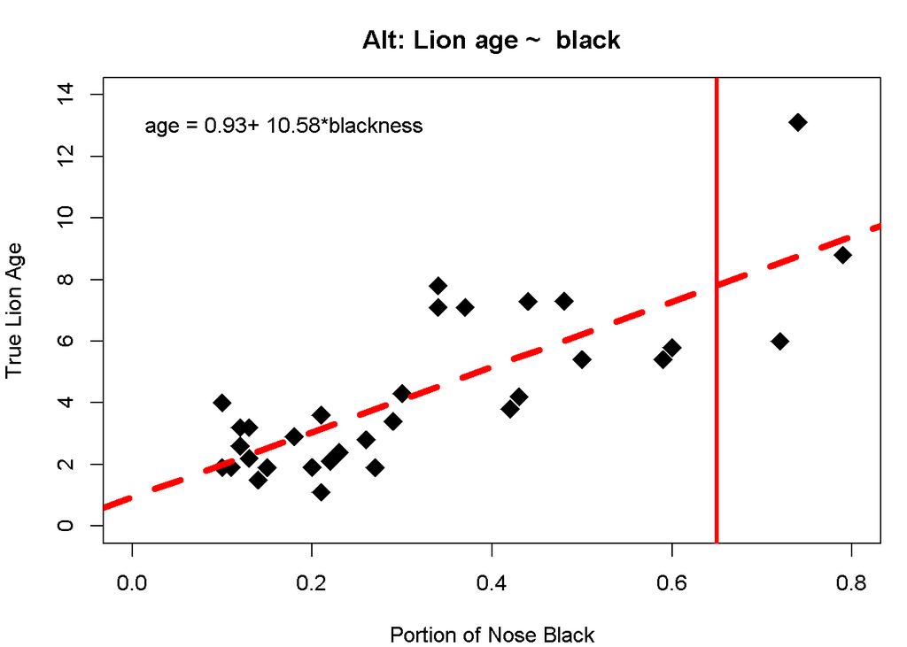

```
##   (Intercept) portion.black
##     0.9262292    10.5826652
```

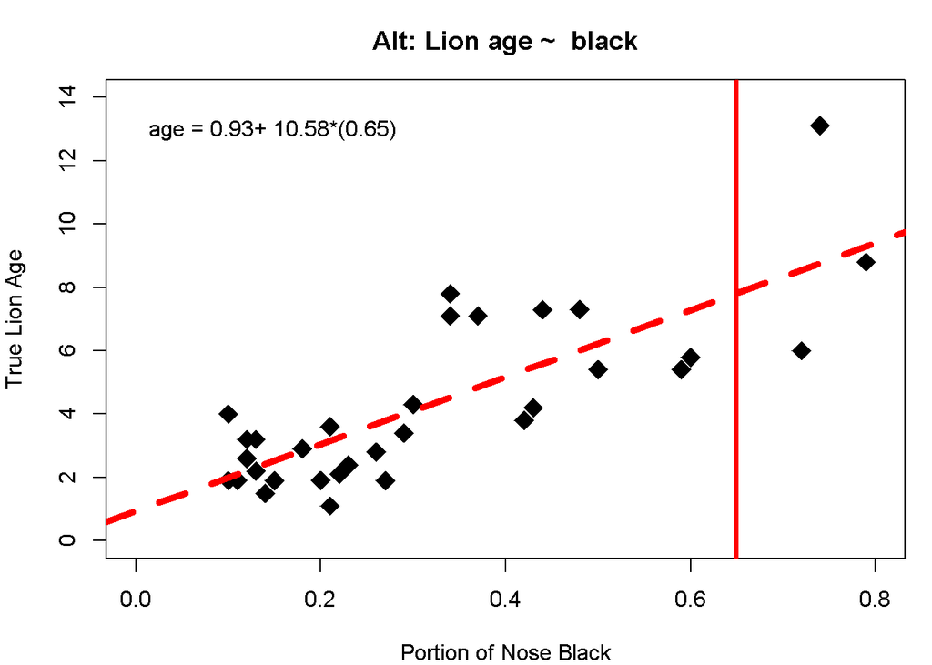

```
##   (Intercept) portion.black
##     0.9262292    10.5826652
```

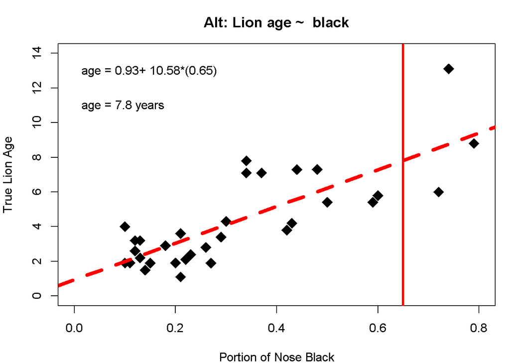

```
##   (Intercept) portion.black
##     0.9262292    10.5826652
```

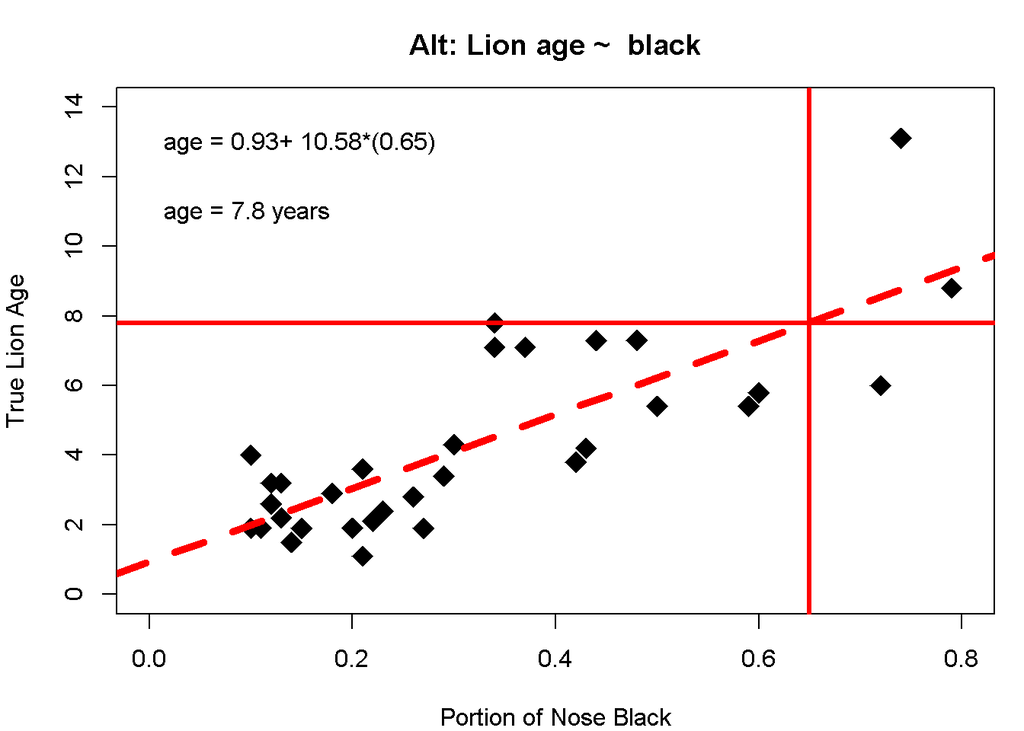

## Getting predictions in R

- Uses predict() function
- I have written a function called easy.predict() to help with this

```r
easy.predict <- function(model,datum){
  x.var.name <- names(model$coefficients)[[2]]
new.df <- data.frame(datum)
names(new.df) <- x.var.name

  predict(model, newdata = new.df)[[1]]
}
```

## Get prediction for portion black = 0.65

```r
easy.predict(lion.alt, datum = 0.65)
```

```
## [1] 7.804962
```

## Plot the prediciton

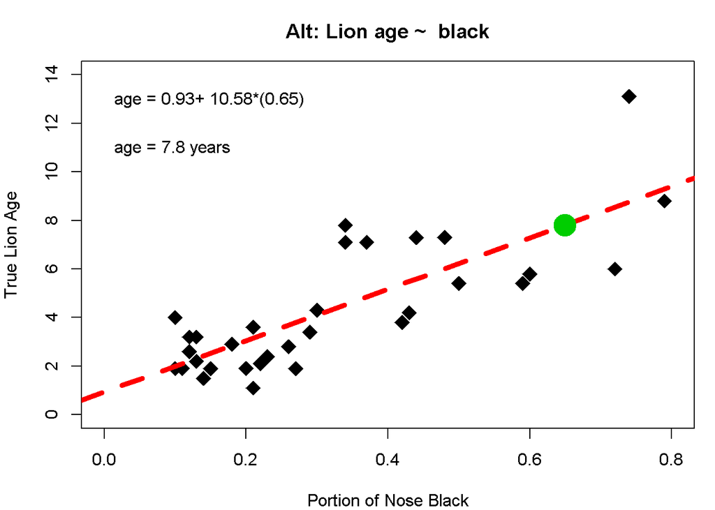

## Is regression appropriate for these data

Do we violate the **assumptions** of the regression model?

## Regression assumptions

Shorthand versions (You MUST know these from memory) * 1)Random sampling * 2)Variability around regression line is approximately normal * 3)Variance in y does not change as x-changes

## Checking Assumption: Model diagnostics

- This can be thought of as “Analysis of the residuals”
- residuals = (real data) - (predictions from model)

You get the residuals in R with the resid() command

```r
#Get the residuals
model.residuals <- resid(lion.alt)

#Look at first 12
model.residuals[1:12]
```

```
##           1           2           3           4           5           6
## -2.04858891 -0.90780235 -0.19032239 -0.10197570  0.40385095  0.89802430
##           7           8           9          10          11          12
##  1.00385095  0.06889104 -0.96024222 -1.15441556 -1.14276226 -0.08449574
```

Note that they can be both positive AND negative. Why is that?

### Assumption 1: random sampling

Frequently violated, especially with regression…

### Assumption 2: normality

#### The most basic model diagnostic: are residuals normal-ish distributed

use the hist() command

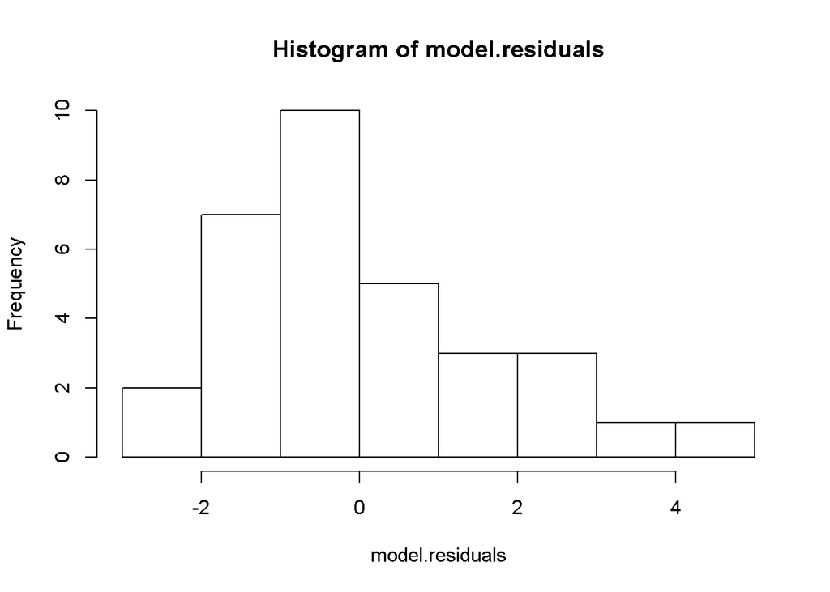

```r
hist(model.residuals)
```

- Kinda look skewed…
- …but not horrible
- Normality is NOT a particularly important assumption

### Assumption 2: Normality

#### Better look at normality: qqplot in R

“qq” = “quantile quantile”

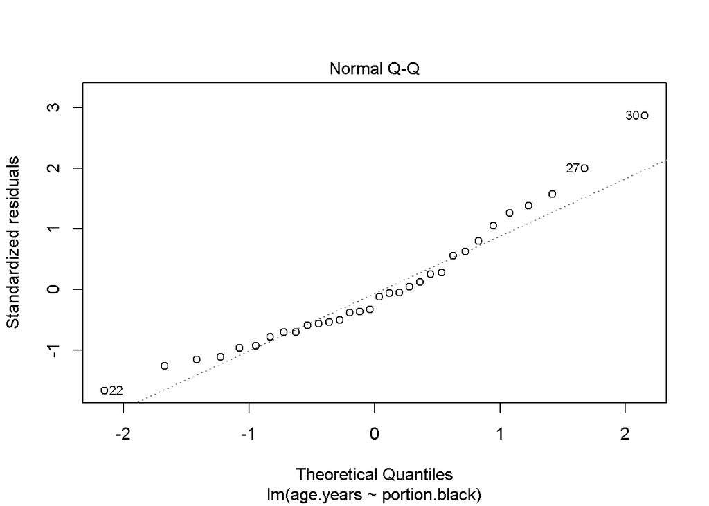

```r
plot(lion.alt, which = 2)
```

### 3: Constant variance

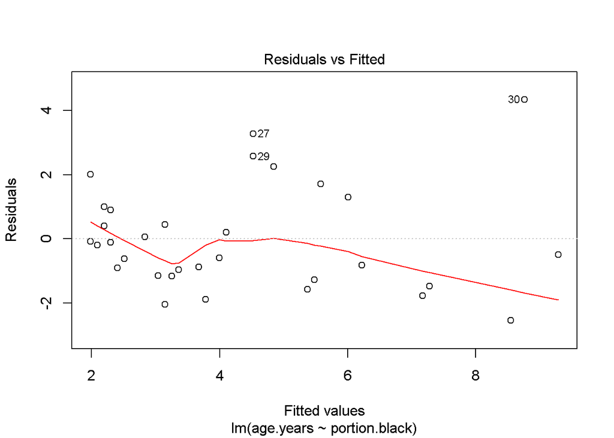

```r
plot(lion.alt, which = 1)
```